# DSM140 Natural Language Processing Coursework

## Text classification with Naїve Bayes Classifier

### Outline:

I. **Introduction**:

- Problem discussion
- Setting of objectives
- Brief dataset description
- Comments on the choice of evaluation strategy

II. **Implementation**:

- Dataset presenation:
  - various visualization
  - simple statiscts
- Data cleaning and deeper analytics
- NLP algorithm implementation and training
- Testing of the algorithm

III. **Conslusion**:

- Evaluation
- Summary and conclusions

# I. INTRODUCTION

## 1. Problem discussion

Text classification (a.k.a. text categorization) is a process of allocation the given textual data sample to the one of the given classes (and further sub-classes if necessary) in supervised learning or clusters in case of unsupervised learning. Text classification includes a variety of problems that can be solved, here are some examples:

1. Sentiment analysis,
2. Subject categorization ,
3. Authorship analysis,
4. News categorization,

and many more.

Source: https://arxiv.org/pdf/2004.03705.pdf , Class notes Topic 4.

The interest of solving the listed problems is quite high in almost any field: business (both off- and on-line, including social media), politics, charity and non-profit, education, security, healthcare, forensic and crime investigations, pure science.

`Sentiment analysis` and `Subject categorization`. Both tasks are constantly performed for functioning and optimization of on-line stores, booking services, streaming services, search engines and social platforms. Sentiment analysis refers to the identification of the polarity of the text – or in modern language they would say – vibe. Analysis of affective states of the comments is used for recommender systems and customer experience analysis, whilst identifying subject of the comment or review/feedback is performed to speed up and improve customer support and chatbots replies. Analysis of society affective states by people social media posts is another area of sentiment analysis and subject categorization application, but here is in interest of government. Another application area is prevention of suicides and violence against third people, offer of support to detected vulnerable people, crime prevention by social media analysis.

`Authorship analysis`. This category includes 3 tasks. First, as comes from the name of the problem, it is the process of identifying author by the given piece of text – Author attribution. Another one is identifying whether the given text belongs to the author - Author verification. And finally, under author is not always meant exact name, but also demographic details like gender or age, and in this case this problem is called Author profiling. There is a wide range of authorship analysis application: plagiarism check, bots reveal, crime and forensic investigations, etc, Sources:

1. https://towardsdatascience.com/authorship-analysis-as-a-text-classification-or-clustering-problem-312549d4a4c0
2. https://andreanini.com/forensic-authorship-analysis/#:~:text=Authorship%20analysis%20is%20the%20application,details%20of%20an%20anonymous%20author

`News categorization`. This is the problem of text classification that I will investigte in the following course work. News categorization consists of 2 sub-categories: news content classification into defined categories (tagging) and fake news detection. Tagging is essential for the recommender system - correct news suggestion to the user, and for engine search – it makes the search process easier, for user too. Importance of fake news detection algorithms is undeniable too. Misleading and fake information costs lives, only to name a few examples: 6th of January 2021 events in USA, forcing of anti-vaccination ideas, 5G conspiracy theories. All the named is dangerous, these topics cause not only polarization of the society, but may push people to rash acts or vice versa - inaction. Information on-line spreads instantly: saw, shared, committed. It is impossible for human beings to check news (and posts) manually – today, 01.01.2022, before 5 pm CET were posted more than 5 million of articles in accordance with https://www.worldometers.info/blogs/. In my opinion fake news (more generally - information) detection is one of the greatest modern tasks in the circumstances of overall internet anonymity and increasing power of it.

## 2. Setting of objectives

Fake news detection problem requires completing tasks as: loading of the dataset; data pre-processing - cleaning, analyzing, vectorization; visualization; building classification model that can confidently distinguish between true and fake news, analyzing performance along with improvements suggestions. Named requires both theoretical knowledge, and practical skills gaining. From the perspective of *theoretical background*, I have to understand:

- Text classification concept and techniques in Natural Language Processing (NLP)
- Connected concepts: tokens, collocations, n-grams, synsets
- Bayes Theorem and Naïve Bayes Classifier principle
- TF-IDF metric concept and text vectorization
- Related KPIs and metrics of text categorization success

In terms of *practical skills* needed to performed named tasks, I set up objective to learn to:

1. Perform operations with Data Frames containing textual data:
   - Filtering operations
   - Joining of two and more Data Frames together
   - Group by operations
   - Summarizing
1. Confidently use NLTK library:
   - Sentence and word tokenization
   - Lemmatization and stemming
   - N-gramms creation
   - Frequency distribution calculation
1. Understand and use regular expressions
1. Textual data visualization
1. Build and evaluate models with Scikit learn:
   - Feature extraction
   - Fit Multinomial Naïve Bayes Classifier on the data
   - Calculate metrics

## 3. Brief dataset description

The source of the data: https://www.kaggle.com/clmentbisaillon/fake-and-real-news-dataset

Dataset consists of two .csv files: one for fake and one for true news. Structure of both files is identical – 4 columns: title, text, subject and date. Title column contains the headline, text column contains news body, subject and date – subject and release date of the news respectively. Even though logically the last column should be of date type, it belongs to the string, just like the first 3 columns – fixing of the data types is a part of cleaning procedure. Overall dataset is balanced – 23481 fake news (52.3%) and 21417 true news (47.7%). True news is equally divided into two categories - world news and politics news, whilst fake news poses 6 categories: government news, middle east, news, US news, left news and politics. The source of the true news is reuter.com (news site), while fake dataset was collected from the variety of unreliable outlet resources posting fake news and marked by Wikipedia and Politifact. Collected news belong to the period from mid 2015 till early 2018.

## 4. Comments on the choice of evaluation strategy

Evaluation strategy depends on the problem - for continuous and discrete output different metrics suits, moreover there could be some specific approaches depending on the exact problem. Evaluation strategy has 2 purposes: evaluate ability of the model to generalize (pure performance) and highlighting possible week sides of the model and/or dataset, potential improvements suggestion. Classification with Naïve Bayes Classifier output discrete result – 0 (True news ) or 1 (Fake news). Hence, speaking of performance metrics, the best choice would be accuracy (overall and per category), precision, recall and F1 score. Together with that confusion matrics is the best approach to visualize model performance. Another way to evalute performance is to read and analyze mispredicted by myself.

Baseline performance I aim to achive is 90%+ accuracy. I think that as long as I cannot perform any changes on dataset (meaning change source, get more samples, etc.) and this work is for academic puposes exclusively this is quite reasonable level. Together with that, I set up 93%+ accuracy for positive class (Fake news) accuracy exclusively.

# II. IMPLEMENTATION

## 1. Dataset presenation and visualisation

#### Preparations and first glance

Here are all the libraries used for the coursework.

```python
#general
import numpy as np
import pandas as pd
import re

#nlp
import nltk
nltk.download('punkt')
from nltk.corpus import stopwords
nltk.download('stopwords')
from nltk.stem import WordNetLemmatizer

#visualization
import matplotlib.pyplot as plt
from pandas.plotting import register_matplotlib_converters
import seaborn as sns
%pip install wordcloud
from wordcloud import WordCloud

#ML
import sklearn
from sklearn.feature_extraction.text import TfidfVectorizer
from sklearn.model_selection import train_test_split
from sklearn.naive_bayes import MultinomialNB
from sklearn import metrics

from pylab import rcParams
rcParams['figure.figsize'] = 14, 6

%matplotlib inline
```

Loading of 2 .csv fikes containing fake and true news respectively:

```python
fake = pd.read_csv('fake.csv')
true = pd.read_csv('true.csv')
```

Brief presentaion of the content of 2 files:

```python
print("Fake dataset contains:", len(fake), "news")
fake.head()
```

```
Fake dataset contains: 23481 news
```

|  | title | text | subject | date |
| --- | --- | --- | --- | --- |
| 0 | Donald Trump Sends Out Embarrassing New Year’... | Donald Trump just couldn t wish all Americans ... | News | December 31, 2017 |
| 1 | Drunk Bragging Trump Staffer Started Russian ... | House Intelligence Committee Chairman Devin Nu... | News | December 31, 2017 |
| 2 | Sheriff David Clarke Becomes An Internet Joke... | On Friday, it was revealed that former Milwauk... | News | December 30, 2017 |
| 3 | Trump Is So Obsessed He Even Has Obama’s Name... | On Christmas day, Donald Trump announced that ... | News | December 29, 2017 |
| 4 | Pope Francis Just Called Out Donald Trump Dur... | Pope Francis used his annual Christmas Day mes... | News | December 25, 2017 |

```python
print("True dataset contains:", len(true), "news")
true.head()
```

```
True dataset contains: 21417 news
```

|  | title | text | subject | date |
| --- | --- | --- | --- | --- |
| 0 | As U.S. budget fight looms, Republicans flip t... | WASHINGTON (Reuters) - The head of a conservat... | politicsNews | December 31, 2017 |
| 1 | U.S. military to accept transgender recruits o... | WASHINGTON (Reuters) - Transgender people will... | politicsNews | December 29, 2017 |
| 2 | Senior U.S. Republican senator: 'Let Mr. Muell... | WASHINGTON (Reuters) - The special counsel inv... | politicsNews | December 31, 2017 |
| 3 | FBI Russia probe helped by Australian diplomat... | WASHINGTON (Reuters) - Trump campaign adviser ... | politicsNews | December 30, 2017 |
| 4 | Trump wants Postal Service to charge 'much mor... | SEATTLE/WASHINGTON (Reuters) - President Donal... | politicsNews | December 29, 2017 |

Joining 2 datasets in one and random shuffle. In order not to distinguish between 2 fake and true news, I add a column with respective class in advance, before joining.

As I try to answer the question 'Is this news fake?', I assign labels as following:

- Fake label: 1
- True label: 0

```python
### adding column with lable to each data set
fake['class'] = 1
true['class'] = 0

#put two dataframes together and shuffle
dataset = (pd.concat([fake, true])).sample(frac=1).reset_index(drop=True)
backup_original = dataset
backup = backup_original
```

```python
dataset.head()
```

|  | title | text | subject | date | class |
| --- | --- | --- | --- | --- | --- |
| 0 | LOL! LEFTIST RAG PUBLISHES Story About How Pre... | You just can t make this stuff up The leftist ... | left-news | Aug 25, 2017 | 1 |
| 1 | LOL! RADIO STATION HOSTS Car Wash For Veterans... | An online radio station based out of Oklahoma ... | left-news | Oct 1, 2017 | 1 |
| 2 | WHOA! Woman Born In NAZI GERMANY Says Trump Do... | A woman who was born in Nazi Germany says that... | left-news | Feb 10, 2017 | 1 |
| 3 | BOOM! REPUBLICAN Wins Montana Election After “... | This is just too rich! The Democrats threw ton... | politics | May 26, 2017 | 1 |
| 4 | GOP MAJORITY SENATE FINALLY GETS IT RIGHT: Vot... | The Democrats tried to attach a gun control am... | Government News | Dec 4, 2015 | 1 |

#### Structure of the dataset

Dataset from the class (true/fake) and subject perspectives.

```python
#get the list of unique subjects and see what are true and fake
unique_subj = pd.DataFrame(dataset.groupby('subject')['title'].count()).rename(columns = {'title':'count'})
unique_class = pd.DataFrame(dataset.groupby('class')['title'].count()).rename(columns = {'title':'count'})

unique_subj_n_class = pd.DataFrame(dataset.groupby(['class', 'subject'])['title'].count()).rename(columns = {'title':'count'})
```

```python
unique_subj
```

| subject | count |
| --- | --- |
| Government News | 1570 |
| Middle-east | 778 |
| News | 9050 |
| US_News | 783 |
| left-news | 4459 |
| politics | 6841 |
| politicsNews | 11272 |
| worldnews | 10145 |

Class perspective:

```python
unique_class
```

| class | count |
| --- | --- |
| 0 | 21417 |
| 1 | 23481 |

Table above shows that dataset is quite balanced - each class constitues nearly a half of it: 21.5 thousands true news and 23.5 thousands of fake news. I find it even better that fake news dataset is somehwat bigger as the task of the coursework is succesfully detect fake news first.

Subject and class perspective combined:

```python
print("Quantity of subjects:", len(unique_subj_n_class))
unique_subj_n_class
```

```
Quantity of subjects: 8
```

| class | subject | count |
| --- | --- | --- |
| 0 | politicsNews | 11272 |
|  | worldnews | 10145 |
| 1 | Government News | 1570 |
|  | Middle-east | 778 |
|  | News | 9050 |
|  | US_News | 783 |
|  | left-news | 4459 |
|  | politics | 6841 |

As per table above, dataset consists of 8 uniqe subjects. 6 of them constitutes fake news and 2 - true news. True news is equally divided between world news and politics, while fake news dataset has quite unbalnced structure in terms of quantity of news in each topic (subject).

Visulization:

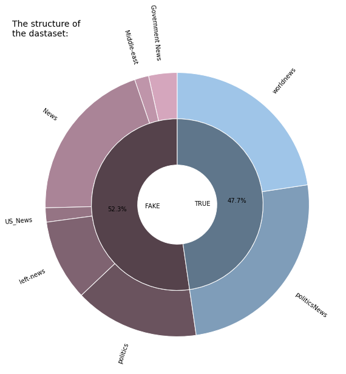

```python
fig, ax = plt.subplots(figsize=(10,10))
size = 0.35

colours_class = ['#55424b', '#5f768b']
colours_subj = ['#d5a6bd', '#bf95aa', '#aa8497', '#957484', '#7f6371', '#6a535e', '#7f9db9','#9fc5e8']

explode_class = (0.09,0.09)
explode_subj = [0.03 for x in range (0, 8)]


#outer pie
ax.pie(unique_subj.values.flatten(), radius=1,
       labels = unique_subj.index,
       colors = colours_subj,
       startangle = 90,
       rotatelabels = True,
       wedgeprops=dict(width=size, edgecolor='w'))

#inner pie
ax.pie(unique_class.sort_index(ascending = False).values.flatten(), radius=1-size,
       labels = ['FAKE','TRUE'],
       colors = colours_class,
       autopct='%1.1f%%',
       pctdistance = 0.7,
       labeldistance=0.2,
       startangle = 90,
       wedgeprops=dict(width=size, edgecolor='w'))

ax.set(aspect="equal")
plt.title('The structure of \nthe dastaset:', fontsize = 14, loc = 'left')
plt.rcParams['font.size'] = 12
plt.show()
```

The plot above visually confirms that dataset is balanced - fake and true news both account for the roughly half of the datasamples - 52.3% and 47.7% respectively.

The sources of ideas for nested asymmetrical piechart:

1. https://stackoverflow.com/questions/67210640/how-can-i-draw-a-nested-pie-graph-in-matplotlib-in-python
2. https://jingwen-z.github.io/data-viz-with-matplotlib-series3-pie-chart/

#### Data distribution in time

The last column left without a comment is a column with date in which news was published. In order to present how news are distributed in time, some pre-processing is required:

```python
print("Date column is not formatted properly:\n")
dataset.info()
```

```
Date column is not formatted properly:

<class 'pandas.core.frame.DataFrame'>
RangeIndex: 44898 entries, 0 to 44897
Data columns (total 5 columns):
title      44898 non-null object
text       44898 non-null object
subject    44898 non-null object
date       44898 non-null object
class      44898 non-null int64
dtypes: int64(1), object(4)
memory usage: 1.7+ MB
```

Together with inappropriate formatting, we need to check whether all the values in date column follows the same pattern. To manage this task I will use the following libraries:

1. **RegEx** to detect outliars in date column
2. **datetime** library to convert date from format `month dd, yyyy` and `dd-mmm-yyyy` to `dd-mm-yyyy`
   - i.e. `January 10, 2000` to `2000-01-10` or `21-Feb-1997` to `1997-02-21`

```python
# find and filter out the outliers
pattern = r"(Jan|Feb|Mar|Apr|May|Jun|Jul|Aug|Sep|Oct|Nov|Dec)" #r"(\w* \d*, \d*)" #|(\d*-\w*-\d*)
dataset['check'] = dataset['date'].str.contains(pattern)
outliers0 = dataset[dataset['check']==False].iloc[:,:5]
dataset = dataset[dataset['check']==True].iloc[:,:5]
print("First of all, here are the caught outliers: \n")
outliers0.head()
```

```
First of all, here are the caught outliers:
```

|  | title | text | subject | date | class |
| --- | --- | --- | --- | --- | --- |
| 4051 | https://fedup.wpengine.com/wp-content/uploads/... | https://fedup.wpengine.com/wp-content/uploads/... | left-news | https://fedup.wpengine.com/wp-content/uploads/... | 1 |
| 5972 | https://fedup.wpengine.com/wp-content/uploads/... | https://fedup.wpengine.com/wp-content/uploads/... | politics | https://fedup.wpengine.com/wp-content/uploads/... | 1 |
| 6153 | https://100percentfedup.com/served-roy-moore-v... | https://100percentfedup.com/served-roy-moore-v... | politics | https://100percentfedup.com/served-roy-moore-v... | 1 |
| 15899 | https://fedup.wpengine.com/wp-content/uploads/... | https://fedup.wpengine.com/wp-content/uploads/... | Government News | https://fedup.wpengine.com/wp-content/uploads/... | 1 |
| 23485 | https://fedup.wpengine.com/wp-content/uploads/... | https://fedup.wpengine.com/wp-content/uploads/... | politics | https://fedup.wpengine.com/wp-content/uploads/... | 1 |

```python
#subset_date['date'] = subset_date['date'].apply(lambda x: datetime.strptime(x, '%B %d, %Y').date())
dataset['date'] = pd.to_datetime(dataset['date'])
backup = dataset
print("Formatted dataset:")
dataset.head()
```

```
Formatted dataset:
```

|  | title | text | subject | date | class |
| --- | --- | --- | --- | --- | --- |
| 0 | LOL! LEFTIST RAG PUBLISHES Story About How Pre... | You just can t make this stuff up The leftist ... | left-news | 2017-08-25 | 1 |
| 1 | LOL! RADIO STATION HOSTS Car Wash For Veterans... | An online radio station based out of Oklahoma ... | left-news | 2017-10-01 | 1 |
| 2 | WHOA! Woman Born In NAZI GERMANY Says Trump Do... | A woman who was born in Nazi Germany says that... | left-news | 2017-02-10 | 1 |
| 3 | BOOM! REPUBLICAN Wins Montana Election After “... | This is just too rich! The Democrats threw ton... | politics | 2017-05-26 | 1 |
| 4 | GOP MAJORITY SENATE FINALLY GETS IT RIGHT: Vot... | The Democrats tried to attach a gun control am... | Government News | 2015-12-04 | 1 |

In order to plot data, I need 2 separates subsets - true and fake:

```python
subset_fake = dataset[dataset['class']==1].groupby('date').count().iloc[:,:1]
subset_true = dataset[dataset['class']==0].groupby('date').count().iloc[:,:1]
```

Plotting process:

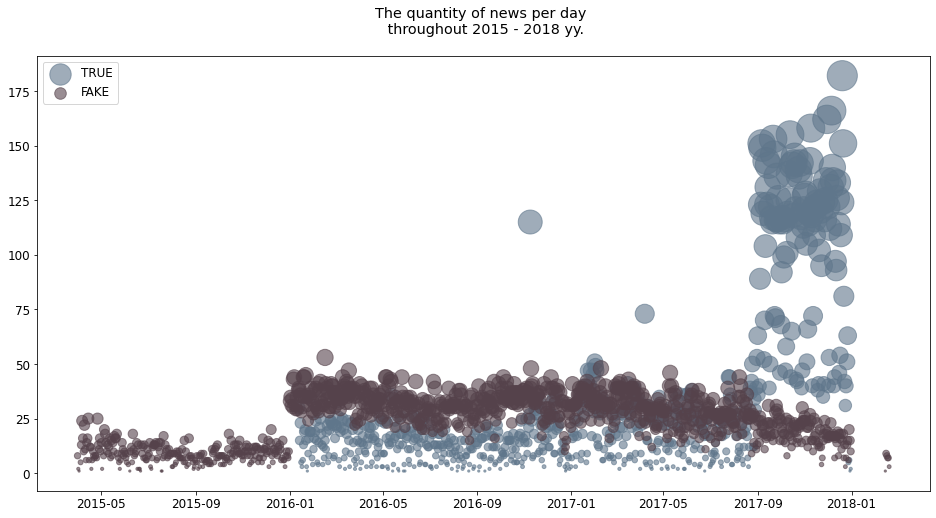

```python
register_matplotlib_converters()

fig, ax = plt.subplots(figsize=(16,8))
colours = ['#55424b', '#5f768b']
sizes_true = subset_true.iloc[:, 0]*5
sizes_fake = subset_fake.iloc[:, 0]*5
plt.scatter(subset_true.index, subset_true.iloc[:, 0],
            color = colours[1], label = "TRUE", alpha = 0.6,
            s = sizes_true)
plt.scatter(subset_fake.index, subset_fake.iloc[:, 0],
            color = colours[0], label = "FAKE", alpha = 0.6,
            s = sizes_fake)
plt.title("The quantity of news per day \n throughout 2015 - 2018 yy.\n")
plt.legend(loc = 'upper left')
plt.show()
```

## 2. Data cleaning and deeper analytics

### 2.1. Simple statistics:

Before dat cleaning, it would be interesitng tocompare the differences between 2 categories (if they are) with the help of some statistical metrics:

- average length* on the news
- standard deviation of the news length
- lexical diversity of the sets
- top 10 from frequency distribution

*length in words

I do this also and after data cleaning.

Here is a custom function that takes news column as input and return a dictionary with average length, standard deviation, maximum and minimum of the news lengths.

```python
#custom helping function #1
def statistics_numbers(column):

    res_dict = {}
    news_len_list = [len(news.split()) for news in column]

    res_dict['Average length'] = int(np.mean(news_len_list))
    res_dict['std'] = int(np.std(news_len_list))
    res_dict['Max length'] = np.max(news_len_list)
    res_dict['Min length'] = np.min(news_len_list)

    for i in res_dict:
        print(i, ":", res_dict[i])

    return res_dict
```

The second function takes tokenized to words news and return anoth dictionary that contains lexical diversity metric and list of 10 most common tokens.

```python
#custom helping function #2
def statistics_textual(words):
    res_dict = {}
    res_dict['Lexical diversity'] = np.round(len(set(words))/len(words), 4)
    res_dict['10 the most common tokens'] = nltk.FreqDist(words).most_common()[:10]

    for i in res_dict:
        print(i, ":", res_dict[i])

    return res_dict
```

Some data pre-processing is required:

```python
#preparation of the data need for statistics metrics calculations:

#separate subsets (here columns) of true and fake news
true_news_col = dataset[dataset['class']==0]['text']
fake_news_col = dataset[dataset['class']==1]['text']

# columns with news converted to lists of words
string_true = str(true_news_col.tolist())
string_fake = str(fake_news_col.tolist())

#news tokenized to words
words_true = nltk.word_tokenize(string_true)
words_fake = nltk.word_tokenize(string_fake)
```

```python
print("True set statistics:\n")
true_statistic_dict = statistics_numbers(true_news_col)
true_text_stat_dict = statistics_textual(words_true)

print("\n-----\n")

print("Fake set statistics:\n")
fake_statistic_dict = statistics_numbers(fake_news_col)
fake_text_stat_dict = statistics_textual(words_fake)
```

```
True set statistics:

Average length : 385
std : 273
Max length : 5172
Min length : 0
Lexical diversity : 0.011
10 the most common tokens : [(',', 427680), ('the', 423433), ('.', 311268), ('to', 244345), ('of', 204566), ('a', 188047), ('and', 179936), ('in', 170268), ('on', 105320), ('s', 99620)]

-----

Fake set statistics:

Average length : 423
std : 408
Max length : 8135
Min length : 0
Lexical diversity : 0.0183
10 the most common tokens : [(',', 507165), ('the', 483871), ('.', 297039), ('to', 287020), ('of', 233766), ('and', 214709), ('a', 203635), ('in', 154161), ('that', 143479), ('s', 128870)]
```

Comments:

1. Both fake, and true sets apparently has some outliars:
   - std of length is quite high for both categories:
     - for fake news in particular it is the same as average length of the news
   - the shortest news of both categories is actualy no news, empty cell
1. I find it interesting that lexical diversity of the fake news is a little bit higher than of the true news. I anticipated true news set to have way higher value of the metric than fake news set.
1. As expected, before cleaning exactely stopwords and punctuiation constitues top 10 most common words for both sets.

### 2.2. Cleaning:

**The standard cleaning involves the follwoinbg steps**:

- outliers detection (e.g. news with less than 10 tokens)
- lower case
- removing confusing tokens like:
  - stopwords
  - punctuation
  - URLs, e-mails, accounts mentioning/tagging (e.g @name)
  - unicode charachters
- normalize text:
  - lemmatization and (or) stemming

```python
print('The dataset after formatted date before cleaning:')
old_length = len(dataset)
dataset.head()
```

```
The dataset after formatted date before cleaning:
```

|  | title | text | subject | date | class |
| --- | --- | --- | --- | --- | --- |
| 0 | LOL! LEFTIST RAG PUBLISHES Story About How Pre... | You just can t make this stuff up The leftist ... | left-news | 2017-08-25 | 1 |
| 1 | LOL! RADIO STATION HOSTS Car Wash For Veterans... | An online radio station based out of Oklahoma ... | left-news | 2017-10-01 | 1 |
| 2 | WHOA! Woman Born In NAZI GERMANY Says Trump Do... | A woman who was born in Nazi Germany says that... | left-news | 2017-02-10 | 1 |
| 3 | BOOM! REPUBLICAN Wins Montana Election After “... | This is just too rich! The Democrats threw ton... | politics | 2017-05-26 | 1 |
| 4 | GOP MAJORITY SENATE FINALLY GETS IT RIGHT: Vot... | The Democrats tried to attach a gun control am... | Government News | 2015-12-04 | 1 |

###### 1. Dealing with too short news

This is clear that legitimate news cannot by empty or contain less than at least several words.

```python
#keep rows containing more than 30 symbols
```

```python
outliers1 = dataset[dataset['text'].str.len()<=30]
outliers1.head()
```

|  | title | text | subject | date | class |
| --- | --- | --- | --- | --- | --- |
| 250 | MUST WATCH COMEDY: ROOM FULL OF DEMS ARE ASKED... |  | politics | 2015-05-20 | 1 |
| 262 | TRUMP SLAMS THE GLOBALISTS: “There is no globa... |  | politics | 2016-12-01 | 1 |
| 305 | “YOU ARE FAKE NEWS!” TRUMP DESTROYS CNN Right ... |  | politics | 2017-01-11 | 1 |
| 321 | WHICH ONE OF THESE PEOPLE Tried to Lecture the... |  | politics | 2017-03-21 | 1 |
| 329 | WOW! 83-YEAR OLD SENATOR Challenged By Teen To... |  | politics | 2017-03-01 | 1 |

```python
print("Outliers quantity:", len(outliers1))
```

```
Outliers quantity: 702
```

```python
outliers1[outliers1['class']==0]
```

|  | title | text | subject | date | class |
| --- | --- | --- | --- | --- | --- |
| 39514 | Graphic: Supreme Court roundup |  | politicsNews | 2016-06-16 | 0 |

```python
dataset['text'] = dataset['title'] + ' ' + dataset['text']
backup = dataset
dataset.drop(['title','subject'], axis = 1, inplace = True)
dataset.head()
```

|  | text | date | class |
| --- | --- | --- | --- |
| 0 | LOL! LEFTIST RAG PUBLISHES Story About How Pre... | 2017-08-25 | 1 |
| 1 | LOL! RADIO STATION HOSTS Car Wash For Veterans... | 2017-10-01 | 1 |
| 2 | WHOA! Woman Born In NAZI GERMANY Says Trump Do... | 2017-02-10 | 1 |
| 3 | BOOM! REPUBLICAN Wins Montana Election After “... | 2017-05-26 | 1 |
| 4 | GOP MAJORITY SENATE FINALLY GETS IT RIGHT: Vot... | 2015-12-04 | 1 |

```python
dataset = dataset[dataset['text'].str.len()>30] #check for outliers again
updated_length = len(dataset)
print("Rows missed while outliers fixing:", old_length - updated_length)
```

```
Rows missed while outliers fixing: 0
```

##### 2. Lowering case

```python
dataset['text'] = dataset['text'].str.lower()
dataset.head()
```

|  | text | date | class |
| --- | --- | --- | --- |
| 0 | lol! leftist rag publishes story about how pre... | 2017-08-25 | 1 |
| 1 | lol! radio station hosts car wash for veterans... | 2017-10-01 | 1 |
| 2 | whoa! woman born in nazi germany says trump do... | 2017-02-10 | 1 |
| 3 | boom! republican wins montana election after “... | 2017-05-26 | 1 |
| 4 | gop majority senate finally gets it right: vot... | 2015-12-04 | 1 |

##### 3. Removing confusing tokens

*Sources of code or/and ideas for this section:*

1. Stopwords and punctuiation removing : https://stackoverflow.com/questions/29523254/python-remove-stop-words-from-pandas-dataframe
2. Removing of Unicode charachters, URLs, e-mail addresses, taggig: https://monkeylearn.com/blog/text-cleaning/ , https://regexr.com/
1. Stopwords and punctuation

```python
stopwords_news = list(stopwords.words('english'))
stopwords_news[:10]
```

```
['i', 'me', 'my', 'myself', 'we', 'our', 'ours', 'ourselves', 'you', "you're"]
```

```python
backup = dataset
dataset['text'] = dataset['text'].apply(lambda row: " ".join([word for word in row.split() if word not in stopwords_news and word.isalnum()]))
dataset.head()
```

|  | text | date | class |
| --- | --- | --- | --- |
| 0 | leftist rag publishes story president trump us... | 2017-08-25 | 1 |
| 1 | radio station hosts car wash nfl jerseys wash ... | 2017-10-01 | 1 |
| 2 | woman born nazi germany says trump remind left... | 2017-02-10 | 1 |
| 3 | republican wins montana election sick tired de... | 2017-05-26 | 1 |
| 4 | gop majority senate finally gets votes gut oba... | 2015-12-04 | 1 |

1. Removing of e-mail addresses, URLs, @ tagging and unicode charachters

```python
pattern0 = r"[^\x00-\x7F]+\ *(?:[^\x00-\x7F]| )*" #unicode
pattern1 = r"(https?:\/\/)?(www\.)?[-a-zA-Z0-9@:%._\+~#=]{1,256}\.[a-zA-Z0-9()]{1,6}\b([-a-zA-Z0-9()@:%_\+.~#?&//=]*)" #URL
pattern2 = r"(^|\W)@\b([-a-zA-Z0-9._]{3,25})\b" #tagging
#e-mail
pattern3 = r"[a-z0-9!#$%&'*+/=?^_`{|}~-]+(?:\.[a-z0-9!#$%&'*+/=?^_`{|}~-]+)*@(?:[a-z0-9](?:[a-z0-9-]*[a-z0-9])?\.)+[a-z0-9](?:[a-z0-9-]*[a-z0-9])?"

patterns = [pattern0, pattern1, pattern2, pattern3]

backup = dataset

for pattern in patterns:
    dataset['text']= dataset['text'].apply(lambda x: re.sub(pattern, " ", x))

dataset.head()
```

|  | text | date | class |
| --- | --- | --- | --- |
| 0 | leftist rag publishes story president trump us... | 2017-08-25 | 1 |
| 1 | radio station hosts car wash nfl jerseys wash ... | 2017-10-01 | 1 |
| 2 | woman born nazi germany says trump remind left... | 2017-02-10 | 1 |
| 3 | republican wins montana election sick tired de... | 2017-05-26 | 1 |
| 4 | gop majority senate finally gets votes gut oba... | 2015-12-04 | 1 |

##### 4. Text normalization

*Sources of code or/and ideas for this section:*

1. Text normalization resources: class notes, Topic 2

Lemmatizing words:

```python
wnl = WordNetLemmatizer()
```

```python
backup = dataset
dataset["text"] = dataset["text"].apply(lambda x: nltk.word_tokenize(x))
dataset["text"] = dataset["text"].apply(lambda x: " ".join([wnl.lemmatize(w) for w in x]))
dataset.head()
```

|  | text | date | class |
| --- | --- | --- | --- |
| 0 | leftist rag publishes story president trump us... | 2017-08-25 | 1 |
| 1 | radio station host car wash nfl jersey wash ca... | 2017-10-01 | 1 |
| 2 | woman born nazi germany say trump remind lefti... | 2017-02-10 | 1 |
| 3 | republican win montana election sick tired dem... | 2017-05-26 | 1 |
| 4 | gop majority senate finally get vote gut obama... | 2015-12-04 | 1 |

And the last step is filtering out too short news that may occure again after data cleaning.

```python
old_length = len(dataset)
dataset = dataset[dataset['text'].str.len()>30]
new_length = len(dataset)
print("Rows missed while outliers fixing:", old_length - updated_length)
```

```
Rows missed while outliers fixing: 0
```

```python
dataset.head()
```

|  | text | date | class |
| --- | --- | --- | --- |
| 0 | leftist rag publishes story president trump us... | 2017-08-25 | 1 |
| 1 | radio station host car wash nfl jersey wash ca... | 2017-10-01 | 1 |
| 2 | woman born nazi germany say trump remind lefti... | 2017-02-10 | 1 |
| 3 | republican win montana election sick tired dem... | 2017-05-26 | 1 |
| 4 | gop majority senate finally get vote gut obama... | 2015-12-04 | 1 |